# Automating ASL Alphabet Recognition Using Deep Learning | CNN

[figure not shown]

```python
import os
import shutil
import random
from pathlib import Path
import matplotlib.pyplot as plt
import matplotlib.image as mpimg
import cv2
import torch.nn as nn
from torchvision.models import resnet50
import cv2
import numpy as np
from sklearn.model_selection import train_test_split
import pandas as pd
import torch.nn.functional as F
```

```python
# Paths to our dataset folders
main_dataset_folder = Path(r"c:\Users\ekyus\Downloads\asl_red\asl_alphabet_train")
data_dir = main_dataset_folder

# Initialize a variable to count images
total_images = 0

# Traverse the directory structure and count image files
for root, dirs, files in os.walk(data_dir):
    for file in files:
        if file.endswith('.jpg') or file.endswith('.png') or file.endswith('.jpeg'):
            total_images += 1

# Print the total number of images
print("Total number of images:", total_images)

# Count the number of image files in the dataset
img_count = len(list(data_dir.glob('*/*.jpg')))

# Read the first image using OpenCV
img = cv2.imread(str(list(data_dir.glob('*/*.jpg'))[0]))
print('Image Dimensions :', img.shape)
```

```
Total number of images: 21870
Image Dimensions : (200, 200, 3)
```

```python
# List all subdirectories (classes)
unique_labels = [label for label in os.listdir(main_dataset_folder) if os.path.isdir(os.path.join(main_dataset_folder, label))]

# Print the number of different labels and the list of unique labels
print("Number of different labels:", len(unique_labels))
print("Unique labels:", unique_labels)
```

```
Number of different labels: 10
Unique labels: ['A', 'B', 'C', 'D', 'E', 'F', 'space', 'X', 'Y', 'Z']
```

Space - Refers to a gesture that represents a blank or empty space. It's used to indicate a separation between two signs or a pause in communication.

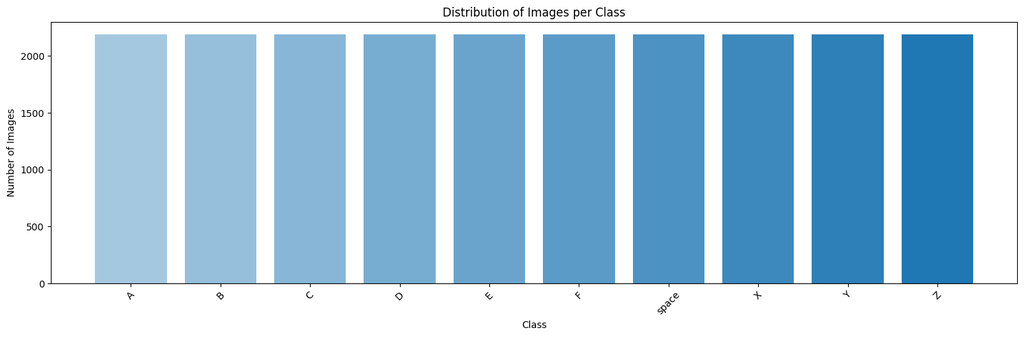

```python
import os
import matplotlib.pyplot as plt
import numpy as np
# List all subdirectories (classes)
classes = os.listdir(main_dataset_folder)

# Initialize a dictionary to store class counts
class_counts = {class_name: 0 for class_name in classes}

# Count the number of images in each class
for class_name in classes:
    class_path = os.path.join(main_dataset_folder, class_name)
    num_images = len(os.listdir(class_path))
    class_counts[class_name] = num_images

# Define a base color
base_color = '#1f77b4'  # A shade of blue

# Create a list of shades of the base color
shades = np.linspace(0.4, 1, len(class_counts))

# Plotting the distribution of images per class with shades of the base color
plt.figure(figsize=(15, 5))
for i, (label, count) in enumerate(class_counts.items()):
    plt.bar(label, count, color=base_color, alpha=shades[i])

plt.title("Distribution of Images per Class")
plt.xlabel("Class")
plt.ylabel("Number of Images")
plt.xticks(rotation=45)
plt.tight_layout()
plt.show()
```

> Our dataset is already balanced in termes of the number of examples for each letter.

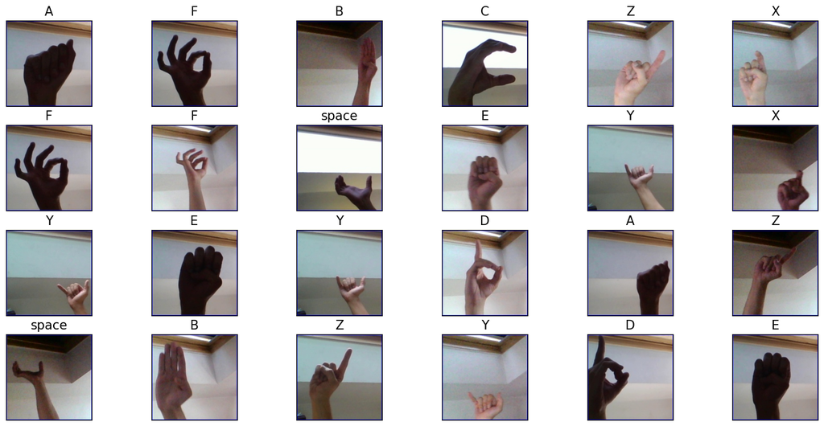

```python
# Number of rows and columns for the grid
num_rows = 4
num_columns = 6

# Initialize a figure for displaying images
fig, axes = plt.subplots(nrows=num_rows, ncols=num_columns, figsize=(15, 7),
                         subplot_kw={'xticks': [], 'yticks': []})

# Loop through each class and display random samples
for i, ax in enumerate(axes.flat):
    class_name = random.choice(classes)
    class_path = os.path.join(main_dataset_folder, class_name)
    class_images = [os.path.join(class_path, img) for img in os.listdir(class_path)]
    random_image_path = random.choice(class_images)

    image = mpimg.imread(random_image_path)
    ax.imshow(image)
    ax.set_title(class_name, fontsize=15)

plt.tight_layout(pad=0.5)
plt.show()
```

```python
# Define image dimensions
img_height = 64
img_width = 64


# Define lists to store image paths and their corresponding labels
image_paths = []
labels = []

# Iterate through each letter directory and collect image paths and labels
letter_dirs = [d for d in os.listdir(main_dataset_folder) if os.path.isdir(os.path.join(main_dataset_folder, d))]
for label, letter_dir in enumerate(letter_dirs):
    letter_path = os.path.join(main_dataset_folder, letter_dir)
    image_files = [f for f in os.listdir(letter_path) if f.endswith('.jpg')]

    for image_file in image_files:
        image_path = os.path.join(letter_path, image_file)
        image_paths.append(image_path)
        labels.append(label)

import concurrent.futures

def preprocess_image(image_path):
    img = cv2.imread(image_path)
    img = cv2.resize(img, (img_width, img_height))
    grayscale_array = cv2.cvtColor((img * 255).astype(np.uint8), cv2.COLOR_RGB2GRAY)
    grayscale_array = grayscale_array / 255
    return grayscale_array


with concurrent.futures.ThreadPoolExecutor(max_workers=16) as executor:
    images = list(executor.map(preprocess_image, image_paths))
# Convert lists to arrays
X = np.array(images)
y = np.array(labels)

# Split the data into train, validation, and test sets
with concurrent.futures.ThreadPoolExecutor(max_workers=16) as executor:
    train_X, test_X, train_y, test_y = train_test_split(X, y, test_size=0.2, random_state=11)
    val_X, test_X, val_y, test_y = train_test_split(test_X, test_y, test_size=0.5, random_state=11)
```

> We have resized the images, convert them tp grayscale and normalize their values concurrently.  
> The processed image arrays are then stored in the X array, while their labels are stored in the y array.

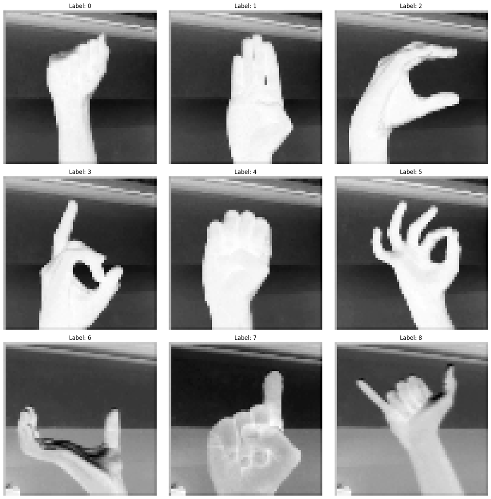

```python
import matplotlib.pyplot as plt

def plot_samples(X, y):
    # Create a dictionary mapping labels to the first example found for each label
    label_sample_map = {}
    for i, label in enumerate(y):
        if label not in label_sample_map:
            label_sample_map[label] = X[i]
        if len(label_sample_map) == len(set(y)):
            break

    # Plot samples
    n = len(label_sample_map)
    sqrt_n = int(n ** 0.5)
    fig, axs = plt.subplots(sqrt_n, sqrt_n, figsize=(15, 15))

    for ax, (label, image) in zip(axs.ravel(), label_sample_map.items()):
        ax.imshow(image, cmap='gray')
        ax.set_title(f'Label: {label}')
        ax.axis('off')

    plt.tight_layout()
    plt.show()

plot_samples(X, y)
```

```python
# Print the number of samples in each set
print("Number of samples in train set:", len(train_X))
print("Number of samples in validation set:", len(val_X))
print("Number of samples in test set:", len(test_X))
```

```
Number of samples in train set: 17496
Number of samples in validation set: 2187
Number of samples in test set: 2187
```

```python
train_X[0].shape
```

```
(64, 64)
```

```python
import torch
import torch.nn as nn
import torch.optim as optim
from torch.utils.data import DataLoader, TensorDataset
from torchvision.models import resnet50
```

```python
device = torch.device("cuda:0" if torch.cuda.is_available() else "cpu")
print(device)
# 1. Convert arrays to PyTorch tensors and normalize them.

x_train, y_train = torch.tensor(train_X).float(), torch.tensor(train_y).long()
x_test, y_test = torch.tensor(test_X).float(), torch.tensor(test_y).long()
x_val, y_val = torch.tensor(val_X).float(), torch.tensor(val_y).long()

# Add channel dimension (grayscale, so only one channel)
x_train, x_test, x_val = x_train.unsqueeze(1), x_test.unsqueeze(1), x_val.unsqueeze(1)

train_data = TensorDataset(x_train, y_train)
test_data = TensorDataset(x_test, y_test)
val_data = TensorDataset(x_val, y_val)

trainloader = DataLoader(train_data, batch_size=512, shuffle=True)
testloader = DataLoader(test_data, batch_size=512, shuffle=False)
valloader = DataLoader(val_data, batch_size=512, shuffle=False)
```

```
cuda:0
```

```python
# Get one batch of data
images, labels = next(iter(trainloader))

# Print the shape
print(images.shape)
torch.Size([512, 1, 64, 64])
```

```
torch.Size([512, 1, 64, 64])
```

[output not shown]

```python
import torch.nn as nn

class CustomModel(nn.Module):
    def __init__(self, num_classes=10):
        super(CustomModel, self).__init__()

        # Convolutional Block 1
        self.conv_block1 = nn.Sequential(
            nn.Conv2d(1, 32, kernel_size=3, padding=1),
            nn.BatchNorm2d(32),
            nn.ReLU(),
            nn.MaxPool2d(kernel_size=2, stride=2)
        )

        # Convolutional Block 2
        self.conv_block2 = nn.Sequential(
            nn.Conv2d(32, 64, kernel_size=3, padding=1),
            nn.BatchNorm2d(64),
            nn.ReLU(),
            nn.MaxPool2d(kernel_size=2, stride=2)
        )

        # Convolutional Block 3
        self.conv_block3 = nn.Sequential(
            nn.Conv2d(64, 128, kernel_size=3, padding=1),
            nn.BatchNorm2d(128),
            nn.ReLU(),
            nn.MaxPool2d(kernel_size=2, stride=2)
        )

        # Fully Connected Layers
        self.fc1 = nn.Linear(128 * 8 * 8, 512)
        self.fc2 = nn.Linear(512, 256)
        self.fc3 = nn.Linear(256, num_classes)

        self.dropout = nn.Dropout(0.5)

    def forward(self, x):
        x = self.conv_block1(x)
        x = self.conv_block2(x)
        x = self.conv_block3(x)

        x = x.view(x.size(0), -1)  # Flatten the tensor

        x = self.dropout(F.relu(self.fc1(x)))
        x = self.dropout(F.relu(self.fc2(x)))
        x = self.fc3(x)

        return x

device = torch.device("cuda:0" if torch.cuda.is_available() else "cpu")
custom_model = CustomModel().to(device)
print(custom_model)
```

```
CustomModel(
  (conv_block1): Sequential(
    (0): Conv2d(1, 32, kernel_size=(3, 3), stride=(1, 1), padding=(1, 1))
    (1): BatchNorm2d(32, eps=1e-05, momentum=0.1, affine=True, track_running_stats=True)
    (2): ReLU()
    (3): MaxPool2d(kernel_size=2, stride=2, padding=0, dilation=1, ceil_mode=False)
  )
  (conv_block2): Sequential(
    (0): Conv2d(32, 64, kernel_size=(3, 3), stride=(1, 1), padding=(1, 1))
    (1): BatchNorm2d(64, eps=1e-05, momentum=0.1, affine=True, track_running_stats=True)
    (2): ReLU()
    (3): MaxPool2d(kernel_size=2, stride=2, padding=0, dilation=1, ceil_mode=False)
  )
  (conv_block3): Sequential(
    (0): Conv2d(64, 128, kernel_size=(3, 3), stride=(1, 1), padding=(1, 1))
    (1): BatchNorm2d(128, eps=1e-05, momentum=0.1, affine=True, track_running_stats=True)
    (2): ReLU()
    (3): MaxPool2d(kernel_size=2, stride=2, padding=0, dilation=1, ceil_mode=False)
  )
  (fc1): Linear(in_features=8192, out_features=512, bias=True)
  (fc2): Linear(in_features=512, out_features=256, bias=True)
  (fc3): Linear(in_features=256, out_features=10, bias=True)
  (dropout): Dropout(p=0.5, inplace=False)
)
```

```python
import torch.optim as optim

# Model, loss criterion, and optimizer instantiation
custom_model = CustomModel().to(device)
criterion = nn.CrossEntropyLoss()
optimizer = optim.Adam(custom_model.parameters(), lr=0.001)

def compute_accuracy(model, dataloader):
    model.eval()
    correct = 0
    total = 0
    with torch.no_grad():
        for inputs, labels in dataloader:
            inputs, labels = inputs.to(device), labels.to(device)
            outputs = model(inputs)
            _, predicted = outputs.max(1)
            total += labels.size(0)
            correct += (predicted == labels).sum().item()
    return 100 * correct / total

# Train the model for 10 epochs
for epoch in range(10):
    custom_model.train()
    running_loss = 0.0
    for i, (inputs, labels) in enumerate(trainloader):
        inputs, labels = inputs.to(device), labels.to(device)

        optimizer.zero_grad()

        outputs = custom_model(inputs)
        loss = criterion(outputs, labels)
        loss.backward()
        optimizer.step()

        running_loss += loss.item()

    # Checking accuracy on the validation data instead of train data
    # to understand how the model is performing on unseen data.
    accuracy = compute_accuracy(custom_model, valloader)
    print(f"Epoch {epoch+1}, Loss: {running_loss/len(trainloader)}, Accuracy on Validation Data: {accuracy:.2f}%")
```

```
Epoch 1, Loss: 1.9077024017061506, Accuracy on Validation Data: 14.86%
Epoch 2, Loss: 1.0094730530466351, Accuracy on Validation Data: 77.87%
Epoch 3, Loss: 0.581699218920299, Accuracy on Validation Data: 68.77%
Epoch 4, Loss: 0.36179433805601935, Accuracy on Validation Data: 94.79%
Epoch 5, Loss: 0.24335969090461732, Accuracy on Validation Data: 94.15%
Epoch 6, Loss: 0.17877296954393387, Accuracy on Validation Data: 97.03%
Epoch 7, Loss: 0.13042316011020116, Accuracy on Validation Data: 98.40%
Epoch 8, Loss: 0.11248213074037007, Accuracy on Validation Data: 98.31%
Epoch 9, Loss: 0.0939484535583428, Accuracy on Validation Data: 98.77%
Epoch 10, Loss: 0.08057038496647562, Accuracy on Validation Data: 97.03%
```

### The model plateaued after epoch 7, so it started to overfit the data.

```python
def evaluate_model(model, dataloader, device):
    model.eval()
    correct = 0
    total = 0
    with torch.no_grad():
        for inputs, labels in dataloader:
            inputs, labels = inputs.to(device), labels.to(device)
            outputs = model(inputs)
            _, predicted = outputs.max(1)
            total += labels.size(0)
            correct += predicted.eq(labels).sum().item()
    accuracy = 100 * correct / total
    return accuracy
```

```python
from sklearn.metrics import precision_score, recall_score, f1_score, confusion_matrix

def evaluate_model_extended(model, dataloader, device):
    model.eval()
    all_preds = []
    all_labels = []

    with torch.no_grad():
        for inputs, labels in dataloader:
            inputs, labels = inputs.to(device), labels.to(device)
            outputs = model(inputs)
            _, predicted = outputs.max(1)
            all_preds.extend(predicted.cpu().numpy())
            all_labels.extend(labels.cpu().numpy())

    accuracy = 100 * sum(np.array(all_preds) == np.array(all_labels)) / len(all_labels)
    precision = precision_score(all_labels, all_preds, average='macro')
    recall = recall_score(all_labels, all_preds, average='macro')
    f1 = f1_score(all_labels, all_preds, average='macro')
    conf_matrix = confusion_matrix(all_labels, all_preds)

    return accuracy, precision, recall, f1, conf_matrix

val_metrics = evaluate_model_extended(custom_model, valloader, device)
test_metrics = evaluate_model_extended(custom_model, testloader, device)

print(f"Validation - Accuracy: {val_metrics[0]:.2f}%, Precision: {val_metrics[1]:.2f}, Recall: {val_metrics[2]:.2f}, F1: {val_metrics[3]:.2f}")
print(f"Test - Accuracy: {test_metrics[0]:.2f}%, Precision: {test_metrics[1]:.2f}, Recall: {test_metrics[2]:.2f}, F1: {test_metrics[3]:.2f}")
print("Validation - Confusion Matrix:")
print(val_metrics[4])
print("Test - Confusion Matrix:")
print(test_metrics[4])
```

[output not shown]

Investigating the data to understand why classes '4' and '1' are frequently confused. Augmenting the training data for underrepresented or challenging classes. Fine-tuning the model or using a different architecture that might capture the differences between confusing classes better. Remember, while the overall accuracy might be high, looking at class-specific metrics, especially for critical or sensitive classes, is essential in many applications

```python
torch.save(custom_model, "new_custom_model.pth")
```

```python
trainloader = DataLoader(train_data, batch_size=256, shuffle=True)  # Reduced from 512 to 256
testloader = DataLoader(test_data, batch_size=256, shuffle=False)
valloader = DataLoader(val_data, batch_size=256, shuffle=False)
```

```python
# 1. Load the pretrained ResNet-50 model
model_pre = resnet50(pretrained=True)

# 2. Modify model
model_pre.conv1 = nn.Conv2d(1, 64, kernel_size=(7, 7), stride=(2, 2), padding=(3, 3), bias=False)
num_ftrs = model_pre.fc.in_features
model_pre.fc = nn.Linear(num_ftrs, 10)
model_pre = model_pre.to(device)

# 3. Specify loss function and optimizer
criterion = nn.CrossEntropyLoss()
optimizer = optim.SGD(model_pre.parameters(), lr=0.001, momentum=0.9)

# 4. Train the model
num_epochs = 10
for epoch in range(num_epochs):

    model_pre.train() # set the model to training mode
    running_loss = 0.0
    total_train_samples = 0

    for i, data in enumerate(trainloader, 0):
        inputs, labels = data[0].to(device), data[1].to(device)

        optimizer.zero_grad()
        outputs = model_pre(inputs)
        loss = criterion(outputs, labels)
        loss.backward()
        optimizer.step()

        running_loss += loss.item() * inputs.size(0)
        total_train_samples += inputs.size(0)

    # Compute average training loss over the entire epoch
    avg_training_loss = running_loss / total_train_samples
    print('Epoch [{}/{}], Loss: {:.4f}'.format(epoch+1, num_epochs, avg_training_loss))

    # Optional: Compute and print validation accuracy
    with torch.no_grad():
        model_pre.eval() # set the model to evaluation mode
        correct = 0
        total = 0
        for images, labels in valloader:  # assuming valloader is your validation dataloader
            images = images.to(device)
            labels = labels.to(device)
            outputs = model_pre(images)
            _, predicted = outputs.max(1)
            total += labels.size(0)
            correct += predicted.eq(labels).sum().item()

        print('Validation Accuracy: {:.4f} %'.format(100 * correct / total))

print('Finished Training')
```

```
Epoch [1/10], Loss: 1.3253
Validation Accuracy: 88.4774 %
Epoch [2/10], Loss: 0.2349
Validation Accuracy: 98.1710 %
Epoch [3/10], Loss: 0.0520
Validation Accuracy: 99.1770 %
Epoch [4/10], Loss: 0.0203
Validation Accuracy: 99.6799 %
Epoch [5/10], Loss: 0.0117
Validation Accuracy: 99.6342 %
Epoch [6/10], Loss: 0.0080
Validation Accuracy: 99.6799 %
Epoch [7/10], Loss: 0.0061
Validation Accuracy: 99.7257 %
Epoch [8/10], Loss: 0.0049
Validation Accuracy: 99.6799 %
Epoch [9/10], Loss: 0.0041
Validation Accuracy: 99.7714 %
Epoch [10/10], Loss: 0.0038
Validation Accuracy: 99.7257 %
Finished Training
```

> The model demonstrates excellent performance, achieving nearly 100% accuracy on the validation dataset by the end of training. This indicates that it has captured the underlying patterns in the data well.

Given the rapid learning in the initial epochs followed by minute improvements in later epochs, it could be inferred that most of the learnable patterns were captured quickly, and the model spent the later epochs refining its knowledge. With the validation accuracy consistently high and very close to 100%, there might be limited room for further improvement.

```python
val_accuracy = evaluate_model(model_pre, valloader, device)
test_accuracy = evaluate_model(model_pre, testloader, device)

print(f"Validation Accuracy: {val_accuracy:.2f}%")
print(f"Test Accuracy: {test_accuracy:.2f}%")
```

```
Validation Accuracy: 99.73%
Test Accuracy: 99.91%
```

```python
val_metrics = evaluate_model_extended(model_pre, valloader, device)
test_metrics = evaluate_model_extended(model_pre, testloader, device)

print(f"Validation - Accuracy: {val_metrics[0]:.2f}%, Precision: {val_metrics[1]:.2f}, Recall: {val_metrics[2]:.2f}, F1: {val_metrics[3]:.2f}")
print(f"Test - Accuracy: {test_metrics[0]:.2f}%, Precision: {test_metrics[1]:.2f}, Recall: {test_metrics[2]:.2f}, F1: {test_metrics[3]:.2f}")
print("Validation - Confusion Matrix:")
print(val_metrics[4])
print("Test - Confusion Matrix:")
print(test_metrics[4])
```

```
Validation - Accuracy: 99.73%, Precision: 1.00, Recall: 1.00, F1: 1.00
Test - Accuracy: 99.91%, Precision: 1.00, Recall: 1.00, F1: 1.00
Validation - Confusion Matrix:
[[227   0   0   1   3   0   0   0   0   0]
 [  0 212   0   0   0   0   0   0   0   0]
 [  0   0 216   0   0   0   0   0   0   0]
 [  0   0   1 200   0   0   0   0   0   0]
 [  0   0   0   0 233   0   0   0   0   0]
 [  0   0   0   0   0 235   0   0   0   0]
 [  0   0   0   0   0   0 210   0   1   0]
 [  0   0   0   0   0   0   0 217   0   0]
 [  0   0   0   0   0   0   0   0 221   0]
 [  0   0   0   0   0   0   0   0   0 210]]
Test - Confusion Matrix:
[[214   1   1   0   0   0   0   0   0   0]
 [  0 224   0   0   0   0   0   0   0   0]
 [  0   0 210   0   0   0   0   0   0   0]
 [  0   0   0 208   0   0   0   0   0   0]
 [  0   0   0   0 198   0   0   0   0   0]
 [  0   0   0   0   0 217   0   0   0   0]
 [  0   0   0   0   0   0 239   0   0   0]
 [  0   0   0   0   0   0   0 235   0   0]
 [  0   0   0   0   0   0   0   0 219   0]
 [  0   0   0   0   0   0   0   0   0 221]]
```

> The model demonstrates top-tier performance on both validation and test datasets. This indicates that it has been effectively trained and has captured the underlying patterns in the data.

The near-perfect precision, recall, and F1 score suggest that the model is not only making correct predictions but is also consistent and reliable in its predictions across different classes. The very few off-diagonal elements in the confusion matrices underline the model's capability to differentiate between the classes with high precision.

```python
torch.save(model_pre, "new_resnet_pre.pth")
```

```python
device = torch.device("cuda:0" if torch.cuda.is_available() else "cpu")
print(device)
# 1. Convert arrays to PyTorch tensors and normalize them.

x_train, y_train = torch.tensor(train_X).float(), torch.tensor(train_y).long()
x_test, y_test = torch.tensor(test_X).float(), torch.tensor(test_y).long()
x_val, y_val = torch.tensor(val_X).float(), torch.tensor(val_y).long()

# Add channel dimension (grayscale, so only one channel)
x_train, x_test, x_val = x_train.unsqueeze(1), x_test.unsqueeze(1), x_val.unsqueeze(1)

train_data = TensorDataset(x_train, y_train)
test_data = TensorDataset(x_test, y_test)
val_data = TensorDataset(x_val, y_val)

trainloader = DataLoader(train_data, batch_size=512, shuffle=True)
testloader = DataLoader(test_data, batch_size=512, shuffle=False)
valloader = DataLoader(val_data, batch_size=512, shuffle=False)
```

```
cuda:0
```

```python
import torch
from torchvision import transforms
from PIL import Image


def preprocess_image_infer(input_image):
    """Preprocess an image for the model."""
    if isinstance(input_image, str):
        img = cv2.imread(input_image)
    else:
        img = np.array(input_image)

    img = cv2.resize(img, (img_width, img_height))
    grayscale_array = cv2.cvtColor((img * 255).astype(np.uint8), cv2.COLOR_RGB2GRAY)

    # Convert to PyTorch tensor and normalize
    tensor = torch.from_numpy(grayscale_array).float().unsqueeze(0) / 255.

    return tensor



def predict(model, input_image):
    """Perform inference on the input image."""
    # Load and transform the image
    image = preprocess_image_infer(input_image)
    image = image.unsqueeze(0).to(device)  # Add batch dimension and send to device

    model.eval()  # Set the model to evaluation mode
    with torch.no_grad():
        outputs = model(image)
        _, predicted_label = torch.max(outputs, 1)
        return predicted_label.item()
```

```python
# Example usage:
image_path = r"c:\Users\ekyus\Downloads\archive (2)\asl_alphabet_test\asl_alphabet_test\F_test.jpg" # Replace with the path to your image
# image_path = r"c:\Users\ekyus\OneDrive\Pictures\space.png" # Replace with the path to your image
image = Image.open(image_path)
predicted_class = predict(model_pre, image)
print(f"Predicted Class: {predicted_class}")
```

```
Predicted Class: 5
```

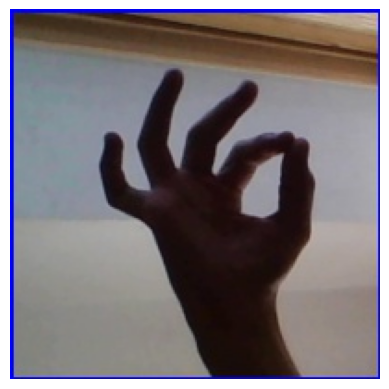

```python
image = Image.open(image_path)
plt.imshow(image)
plt.axis('off')  # Turn off the axis numbers
plt.show()
```